# MM02_B10705024_楊中

## (a)

### Code

```python
import numpy as np
size = 2000
HS_math_GPA = np.random.normal(3.5, 0.5, size)
HS_calculus = np.zeros(size)
NTU_precalculus = np.zeros(size)
NTU_Calculus_I_grade = np.zeros(size)
true_sigma = 0.5
coefficient = {"Intercept":0.3,
               "hs_math_gpa":0.7,
               "hs_calculus":0.3,
               "uw_precalc":0.1}
for i in range(0, size) :
    if(HS_math_GPA[i] < 2) :
        HS_math_GPA[i] = 2
    elif(HS_math_GPA[i] > 4) :
        HS_math_GPA[i] = 4

    p = 0
    if(HS_math_GPA[i] > 3.6) :
        p = 0.75
    else :
        p = 0.4
    HS_calculus[i] = np.random.binomial(1, p, 1)

    if(HS_calculus[i] == 0) :
        p = 0.7
    elif(HS_math_GPA[i] < 3.5) :
        p = 0.6
    else :
        p = 0.25
    NTU_precalculus[i] = np.random.binomial(1, p, 1) #sigma follow N(0, 0,5)

    sigma = np.random.normal(0, true_sigma, 1)
    NTU_Calculus_I_grade[i] = coefficient["Intercept"]+coefficient["hs_math_gpa"]*HS_math_GPA[i]+coefficient["hs_calculus"]*HS_calculus[i]+coefficient["uw_precalc"]*NTU_precalculus[i]+sigma
    NTU_Calculus_I_grade[i] = np.round(NTU_Calculus_I_grade[i], 1)
    if(NTU_Calculus_I_grade[i] < 0) :
        NTU_Calculus_I_grade[i] = 0
    elif(NTU_Calculus_I_grade[i] > 4) :
        NTU_Calculus_I_grade[i] = 4
    elif(NTU_Calculus_I_grade[i] < 0.7) :
        NTU_Calculus_I_grade[i] = 0.7

import pandas as pd
data = np.vstack((NTU_Calculus_I_grade, HS_math_GPA, HS_calculus, NTU_precalculus))
df = pd.DataFrame(data.T , columns = ["NTU_Calculus_I_grade", "HS_math_GPA", "HS_calculus", "NTU_precalculus"] )
print(df)
```

```
      NTU_Calculus_I_grade  HS_math_GPA  HS_calculus  NTU_precalculus
0                      3.1     4.000000          0.0              0.0
1                      2.5     3.488347          1.0              1.0
2                      2.8     3.581591          1.0              1.0
3                      2.9     3.905229          1.0              1.0
4                      2.9     3.361566          0.0              0.0
...                    ...          ...          ...              ...
1995                   2.6     3.279093          1.0              0.0
1996                   3.2     3.327944          0.0              1.0
1997                   3.4     3.732490          1.0              1.0
1998                   3.3     3.298081          0.0              1.0
1999                   2.5     3.279262          1.0              1.0

[2000 rows x 4 columns]
```

### Explain your answer

I build three random variable with matirx and np.random, then determine the NTU_Calculus_I_grade.

## (b)

### What you think

We can rewrite the line equation $y = mx + c$ as $y = AP$, where $A = [x$ $1]$ and $P = [[m], [c]]$ Then by `np.linalg.lstsq`, we can solve the $m$ and $c$  
After the individual linear regression, then we can build the Multidimensional linear models.

### Code

```
y = mx + c, m: 0.7569778107506611 c: 0.3063684912796298
```

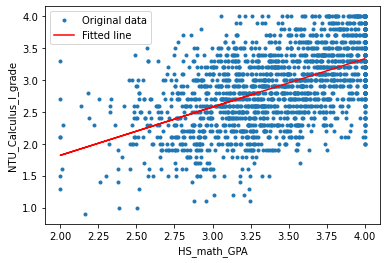

```
y = mx + c, m: 0.49161401941389604 c: 2.6373167981961676
```

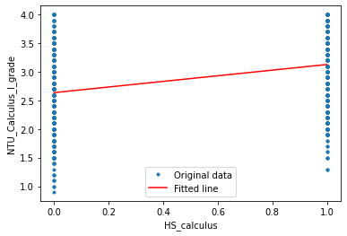

```
y = mx + c, m: -0.1254260362611336 c: 2.975619834710745
```

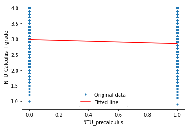

```
Multidimensional linear models(by numpy.linalg.lstsq) :
y = β1 + β2 * HS_math_GPA + β3 * HS_calculus + β4 * NTU_precalculus
β1: 0.36634574593778957 β2: 0.6658786597531314 β3: 0.35922524765664265 β4: 0.10379553833988515
residual_square by numpy.linalg.lstsq: [[452.71847948]]

Multidimensional linear models(by statsmodels.api) :
                            OLS Regression Results
==============================================================================
Dep. Variable:                      y   R-squared:                       0.373
Model:                            OLS   Adj. R-squared:                  0.372
Method:                 Least Squares   F-statistic:                     395.2
Date:                Tue, 26 Apr 2022   Prob (F-statistic):          1.88e-201
Time:                        14:44:49   Log-Likelihood:                -1352.2
No. Observations:                2000   AIC:                             2712.
Df Residuals:                    1996   BIC:                             2735.
Df Model:                           3
Covariance Type:            nonrobust
==============================================================================
                 coef    std err          t      P>|t|      [0.025      0.975]
------------------------------------------------------------------------------
const          0.3663      0.091      4.042      0.000       0.189       0.544
x1             0.6659      0.026     25.661      0.000       0.615       0.717
x2             0.3592      0.023     15.546      0.000       0.314       0.405
x3             0.1038      0.023      4.603      0.000       0.060       0.148
==============================================================================
Omnibus:                       13.455   Durbin-Watson:                   2.057
Prob(Omnibus):                  0.001   Jarque-Bera (JB):               12.954
Skew:                          -0.168   Prob(JB):                      0.00154
Kurtosis:                       2.795   Cond. No.                         32.7
==============================================================================

Notes:
[1] Standard Errors assume that the covariance matrix of the errors is correctly specified.
```

```python
import matplotlib.pyplot as plt
A = np.vstack([HS_math_GPA, np.ones(size)]).T
m, c = np.linalg.lstsq(A, NTU_Calculus_I_grade, rcond=None)[0]
print("y = mx + c, m:", m, "c:", c)
plt.plot(HS_math_GPA, NTU_Calculus_I_grade, 'o', label='Original data', markersize=3)
plt.plot(HS_math_GPA, m*HS_math_GPA + c, 'r', label='Fitted line')
plt.xlabel('HS_math_GPA',fontsize=10)
plt.ylabel('NTU_Calculus_I_grade',fontsize=10)
plt.legend()
plt.show()

A = np.vstack([HS_calculus, np.ones(size)]).T
m, c = np.linalg.lstsq(A, NTU_Calculus_I_grade, rcond=None)[0]
print("y = mx + c, m:", m, "c:", c)
plt.plot(HS_calculus, NTU_Calculus_I_grade, 'o', label='Original data', markersize=3)
plt.plot(HS_calculus, m*HS_calculus + c, 'r', label='Fitted line')
plt.xlabel('HS_calculus',fontsize=10)
plt.ylabel('NTU_Calculus_I_grade',fontsize=10)
plt.legend()
plt.show()

A = np.vstack([NTU_precalculus, np.ones(size)]).T
m, c = np.linalg.lstsq(A, NTU_Calculus_I_grade, rcond=None)[0]
print("y = mx + c, m:", m, "c:", c)
plt.plot(NTU_precalculus, NTU_Calculus_I_grade, 'o', label='Original data', markersize=3)
plt.plot(NTU_precalculus, m*NTU_precalculus + c, 'r', label='Fitted line')
plt.xlabel('NTU_precalculus',fontsize=10)
plt.ylabel('NTU_Calculus_I_grade',fontsize=10)
plt.legend()
plt.show()

print("Multidimensional linear models(by numpy.linalg.lstsq) :")
X = np.mat([np.ones(size), HS_math_GPA, HS_calculus, NTU_precalculus]).T
Y = np.mat([NTU_Calculus_I_grade]).T
W = np.linalg.lstsq(X, Y, -1)[0]
print("y = β1 + β2 * HS_math_GPA + β3 * HS_calculus + β4 * NTU_precalculus")
print("β1:", W[0, 0], "β2:", W[1, 0], "β3:", W[2, 0], "β4:", W[3, 0])
print("residual_square by numpy.linalg.lstsq:", np.linalg.lstsq(X, Y, -1)[1])
print()
import statsmodels.api as sm
mod = sm.OLS(NTU_Calculus_I_grade, X)
res = mod.fit()
print("Multidimensional linear models(by statsmodels.api) :")
print(res.summary())
```

### Explain your answer

I solve the $m$ and $c$ by `np.linalg.lstsq`, then visualize my answer by `matplotlib.pyplot`.  
Then solve the Multidimensional linear models with `np.linalg.lstsq` and `statsmodels.api`.

## (c)

### What you think

Build the matrix $Χ$ (intercept plus independent variables) and variable $y$ (dependent variable)

### Code

```python
X = np.mat([np.ones(size), HS_math_GPA, HS_calculus, NTU_precalculus]).T
y = np.mat([NTU_Calculus_I_grade]).T
```

### Explain your answer

Literally setup the matrix $X$ and $y$.

## (d)

### Code

```python
C = X.T * X
inv_C = np.linalg.inv(C)
det_C = np.linalg.det(C)
adj_C = det_C * inv_C
print("inv_C:")
print(inv_C)
print("det_C:")
print(det_C)
print("adj_C:")
print(adj_C)
```

```
inv_C:
[[ 0.0362173  -0.01005622  0.0005231  -0.00272867]
 [-0.01005622  0.00296876 -0.00062046  0.0003622 ]
 [ 0.0005231  -0.00062046  0.00235397  0.00058474]
 [-0.00272867  0.0003622   0.00058474  0.00224234]]
det_C:
151281755728.69876
adj_C:
[[ 5.47901628e+09 -1.52132261e+09  7.91353687e+07 -4.12797761e+08]
 [-1.52132261e+09  4.49119512e+08 -9.38641033e+07  5.47939748e+07]
 [ 7.91353687e+07 -9.38641033e+07  3.56113036e+08  8.84606455e+07]
 [-4.12797761e+08  5.47939748e+07  8.84606455e+07  3.39224671e+08]]
```

## (e)

### What you think

Find $\hat{𝛽̂}$ = $(𝑋^{T}𝑋)^{-1}𝑋^{𝑇}𝑦$, residuals, residual variance $𝜎̂^2$,standard errors of the covariance matrix $Var\hat{𝛽̂}$.

### Code

```python
import math
beta_hat = inv_C * X.T * y
p = 3
residual = 0
residual_square = 0
residual_var = 0
cov = 0
N = X * beta_hat
for i in range(0, size) :
    residual = residual + Y[i] - N[i]
    residual_square = residual_square + (Y[i] - N[i])**2
print("residual_square:")
print(residual_square)
print("residual:")
print(residual[0, 0])
residual_var = (Y - N).T * (Y - N) / (size-p-1)
print("residual_var:")
print(residual_var[0, 0])
cov = residual_var[0, 0] * inv_C
print("Covariance:")
print(cov)
beta_SE = np.zeros(p+1)
for i in range(0, p+1) :
    beta_SE[i] = math.sqrt(cov[i, i])
print("beta_SE:")
print(beta_SE)
```

```
residual_square:
[[452.71847948]]
residual:
4.186384572335555e-11
residual_var:
0.22681286546943677
Covariance:
[[ 8.21454892e-03 -2.28088006e-03  1.18645633e-04 -6.18897120e-04]
 [-2.28088006e-03  6.73353393e-04 -1.40728048e-04  8.21512044e-05]
 [ 1.18645633e-04 -1.40728048e-04  5.33911163e-04  1.32626782e-04]
 [-6.18897120e-04  8.21512044e-05  1.32626782e-04  5.08590869e-04]]
beta_SE:
[0.09063415 0.02594905 0.02310652 0.02255196]
```

### Explain your answer

Successfully find $\hat{𝛽̂}$ = $(𝑋^{T}𝑋)^{-1}𝑋^{𝑇}𝑦$, residuals, residual variance $𝜎̂^2$,standard errors of the covariance matrix $Var\hat{𝛽̂}$.

## (f)

### What you think

Build a table of the true coefficient, the manual coefficient, and the coefficient computed by `statsmodels.api` to see what is different between them.

### Code

```python
import pandas as pd
data = np.vstack(([0.3, 0.7, 0.3, 0.1], beta_hat.T, res.params))
df = pd.DataFrame(data.T ,index = ["intercept", "HS_math_GPA", "HS_calculus", "NTU_precalculus"], columns = ["Truth", "Manual", "lstsq"] )
print(df)
```

```
                 Truth    Manual     lstsq
intercept          0.3  0.366346  0.366346
HS_math_GPA        0.7  0.665879  0.665879
HS_calculus        0.3  0.359225  0.359225
NTU_precalculus    0.1  0.103796  0.103796
```

### Explain your answer

Observing the table, I find the coefficient we computed is the same as the coefficient computed by `statsmodels.api`, and the coefficient we got is quite close to the true coefficient

## (g)

### What you think

Compute the results of the estimated standard errors $(\hat{Var}(\hat{𝛽̂}))^{0.5}$ and observe the result.

### Code

```python
true_cov = true_sigma**2 * inv_C
true_SE = np.zeros(p+1)
for i in range(0, p+1) :
    true_SE[i] = math.sqrt(true_cov[i, i])
data = np.vstack((true_SE, beta_SE, res.bse)).T
df = pd.DataFrame(data ,index = ["intercept", "HS_math_GPA", "HS_calculus", "NTU_precalculus"], columns = ["Truth", "Manual", "lstsq"] )
print(df)
```

```
                    Truth    Manual     lstsq
intercept        0.095154  0.090634  0.090634
HS_math_GPA      0.027243  0.025949  0.025949
HS_calculus      0.024259  0.023107  0.023107
NTU_precalculus  0.023677  0.022552  0.022552
```

### Explain your answer

With `statsmodels.api`, I find the standard error is the same as the standard error computed by ourselves, and the value is quite close to the true standard error.

## (f)

### Code

```python
data = np.vstack((true_sigma**2, residual_var[0, 0], res.mse_resid)).T
df = pd.DataFrame(data, index = [""], columns = ["Truth", "Manual", "lstsq"] )
print(df)
```

```
  Truth    Manual     lstsq
   0.25  0.226813  0.226813
```

### Explain your answer

With `statsmodels.api`, I find the residual variance is the same as the residual variance computed by ourselves, and the value is quite close to the true residual variance.

## (g)

### What you think

Predict a new data and observe the result

### Code

```python
HS_math_GPA_new = 3.123456
HS_calculus_new = 1
NTU_precalculus_new = 0
M = [1, HS_math_GPA_new, HS_calculus_new, NTU_precalculus_new]
NTU_Calculus_I_grade_new_manual = M * beta_hat
sigma = np.random.normal(0, true_sigma, 1)
NTU_Calculus_I_grade_new_true = coefficient["Intercept"]+coefficient["hs_math_gpa"]*HS_math_GPA_new+coefficient["hs_calculus"]*HS_calculus_new+coefficient["uw_precalc"]*NTU_precalculus_new+sigma
if(NTU_Calculus_I_grade_new_true < 0) :
    NTU_Calculus_I_grade_new_true = 0
elif(NTU_Calculus_I_grade_new_true > 4) :
    NTU_Calculus_I_grade_new_true = 4
elif(NTU_Calculus_I_grade_new_true < 0.7) :
    NTU_Calculus_I_grade_new_true = 0.7
data = [(NTU_Calculus_I_grade_new_true[0], NTU_Calculus_I_grade_new_manual[0, 0], (M * np.mat(res.params).T)[0, 0])]
df = pd.DataFrame(data ,index = [""], columns = ["Truth", "Manual", "lstsq"] )
print(df)
```

```
     Truth    Manual     lstsq
  3.184325  2.805414  2.805414
```

### Explain your answer

The prediction done by me and `statsmodels.api` is the same.  
However, the difference between the prediction and the true value must be a $𝜀$, which follows $N(0, 0.5)$